# Machine learning - HW1

# Navid Ashraf

## libraries:

```python
import numpy as np
import matplotlib.pyplot as plt
```

## Question 1

Given random variable X distributed noramlly($ X\sim N(m,s^2) $) calculate Y = aX + b distribution.

## Answer:

We have $ m = E[X] $ and $s^2 = Var(X)$. We have to calculate $ E[Y]$ and $Var(Y)$
$E[Y] = E[aX + b] = E[aX] + b = aE[x] + b = $ **am + b**
$Var(Y) = Var(aX + b) = Var(aX) = a^2Var(X) = a^2s^2$
so we have: **$$Y\sim N(am + b,a^2s^2)$$**

## Question 2

Write a python program that produces 5 random variables considering $m = E[X] = 2$ and $s = Var(x) = 1.5$ then calculate E[X] and Var(X) of random variables and compare them to m and s.  
run program for N = 5, 10, 50, 100, 500, 1000 and plot E[x] and Var(x) based on the number of samples.  
for N = 10, 50 draw their histogram.

## Answer

a)

```python
mu = 2
sigma = 1.5
n = 5
x = np.random.normal(mu, sigma, n)
print ("mean:\t\t", np.mean(x), "\tm: ", mu)
print ("variance:\t", np.std(x, ddof=1),"\ts: ",sigma)
```

```
mean:		 3.3367926414436213 	m:  2
variance:	 2.202766517931983 	s:  1.5
```

b)

```
number of samples:  5
mean:		 2.213380025317774 	m:  2
variance:	 1.26450787481158 	s:  1.5

number of samples:  10
mean:		 1.4754239961089861 	m:  2
variance:	 1.3184884278547853 	s:  1.5

number of samples:  50
mean:		 1.9780774161970358 	m:  2
variance:	 1.4012096282737438 	s:  1.5

number of samples:  100
mean:		 2.01433117109588 	m:  2
variance:	 1.485045637832246 	s:  1.5

number of samples:  500
mean:		 2.1173847299673545 	m:  2
variance:	 1.5999961901577593 	s:  1.5

number of samples:  1000
mean:		 1.9604602731824807 	m:  2
variance:	 1.4562911357005208 	s:  1.5
```

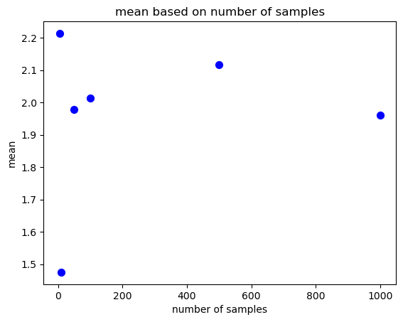

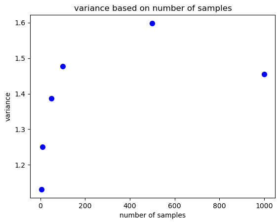

```python
y = []
number = []
#create samples
for i in range(6):
    #justify n
    n = pow(10,int(i/2)+1)
    if(i%2 == 0):
        n = int(n/2)
    number.append(n)
    #add samples to array
    y.append(np.random.normal(mu, sigma, n))
fig = plt.figure()
for i in range(6):
    print("number of samples: ", number[i])
    print("mean:\t\t", np.mean(y[i]), "\tm: ", mu)
    print ("variance:\t", np.std(y[i], ddof=1),"\ts: ",sigma,"\n")
    plt.scatter(number[i], np.mean(y[i]), s = 50, c = "blue")

plt.xlabel('number of samples')
plt.ylabel('mean')
plt.title("mean based on number of samples")
plt.show()

for i in range(6):
    plt.scatter(number[i], np.std(y[i]), s = 50, c = "blue")

plt.xlabel('number of samples')
plt.ylabel('variance')
plt.title("variance based on number of samples")
plt.show()
```

c)

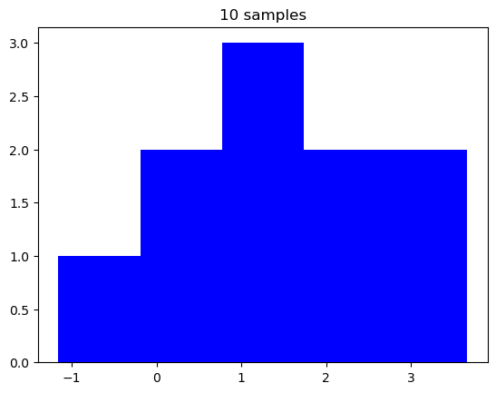

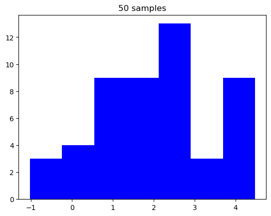

```python
plt.hist(x=y[1], bins='auto', color='blue', rwidth=1)
plt.title("10 samples")
plt.show()
plt.hist(x=y[2], bins='auto', color='blue', rwidth=1)
plt.title("50 samples")
plt.show()
```

## Question 3

write a program that produces 60 random variables using uniform distribution then draw its histogram(bin = 6).

## Answer:

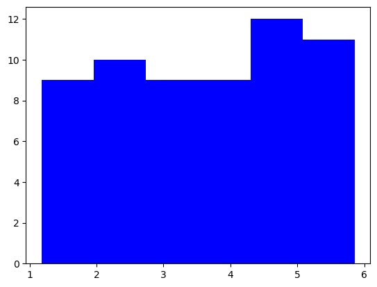

```python
QThreeSample = np.random.uniform(low=1.0, high=6.0, size=60)
plt.hist(x=QThreeSample, bins=6, color='blue', rwidth=1)
plt.show()
```

## Question 4

write a program that produces 20 2D data X=[X1,X2] with independent distributions $ X_{1}\sim N(m_{1},s_{1}^2) $ and $ X_{2}\sim N(m_{2},s_{2}^2) $ draw them in 2 dimensional space.  
write 2 dimensional distribution function of X.  
$m_{1} = 0.5, m_{2} = 0.5$  
$s_{1}^2 = 0.1, s_{2}^2 = 0.1$  
$\Sigma = \begin{pmatrix} 0.1 & ?\\ ? & 0.1 \end{pmatrix}$

## Answer:

$\Sigma = \begin{pmatrix} V(x_{1}) & COV(x_{1},x_{2})\\ COV(x_{2},x_{1}) & V(x_{2}) \end{pmatrix}$
$COV(x_{i},x_{j}) = E[(Y_{i} - E[Y_{i}])(Y_{j} - E[Y_{j} ])] = E[Y_{i}Y_{j} ] - E[Y_{i}]E[Y_{j} ]$
in 2D $\Sigma = \begin{pmatrix} s_{1}^2 & s_{12}^2\\ s_{21}^2 & s_{2}^2 \end{pmatrix} = \begin{pmatrix} s_{1}^2 & \rho s_{1}s_{2}\\ \rho s_{1}s_{2} & s_{2}^2 \end{pmatrix}$ where $\rho$ is correlation coefficient and equals to $\frac{Cov(x_{1},x_{2})}{\sqrt{V(x_{1})V(x_{2})}} = \frac{s_{12}^2}{s_{1}s_{2}}$
since x1 and x2 are independent then $\rho = 0$ and $\Sigma = \begin{pmatrix} 0.1 & 0\\ 0 & 0.1 \end{pmatrix} $
finally distribution function of x is: $$ N(X|\mu,\Sigma) = \frac{1}{2\pi|\Sigma|^{1/2}}exp[-\frac{1}{2}(X-\mu)^T\Sigma^{-1}(X-\mu)] $$
$$ where: \mu = \begin{pmatrix} m_{1}\\ m_{2} \end{pmatrix} = \begin{pmatrix} 0.5\\ 0.5 \end{pmatrix} and \Sigma = \begin{pmatrix} 0.1 & 0\\ 0 & 0.1 \end{pmatrix} $$

```
(-3.0, 2.0)
```

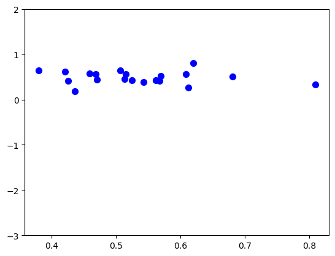

```python
mu1, mu2 = 0.5, 0.5
sigma1, sigma2 = 0.1, 0.1
n = 20
x1 = np.random.normal(mu1, sigma1, n)
x2 = np.random.normal(mu2, sigma2, n)
x=[x1, x2]
plt.scatter(x1,x2, s = 50, c = "blue")
plt.ylim(-3, 2)
```

## Question 5

run program from previous question using new given parameters:  
$m_{1} = 0.5, m_{2} = -0.5$  
$s_{1}^2 = 0.1, s_{2}^2 = 1.0$  
$\Sigma = \begin{pmatrix} 0.1 & ?\\ ? & 1.0 \end{pmatrix}$  
explain the differences between results.

## Answer:

distribution function of x is: $$ N(X|\mu,\Sigma) = \frac{1}{2\pi|\Sigma|^{1/2}}exp[-\frac{1}{2}(X-\mu)^T\Sigma^{-1}(X-\mu)] $$
$$ where: \mu = \begin{pmatrix} m_{1}\\ m_{2} \end{pmatrix} = \begin{pmatrix} 0.5\\ -0.5 \end{pmatrix} and \Sigma = \begin{pmatrix} 0.1 & 0\\ 0 & 1.0 \end{pmatrix} $$

```
(-3.0, 2.0)
```

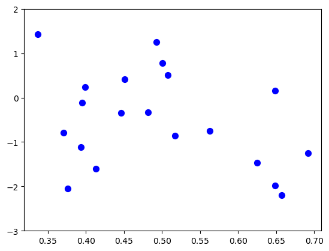

```python
mu1, mu2 = 0.5, -0.5
sigma1, sigma2 = 0.1, 1
n = 20
x1 = np.random.normal(mu1, sigma1, n)
x2 = np.random.normal(mu2, sigma2, n)
x=[x1, x2]
plt.scatter(x1,x2, s = 50, c = "blue")
plt.ylim(-3, 2)
```

As we can see, center of samples in x2 direction moved downward in comparison to the samples from question 4(from 0.5 to -0.5).  
that's because of the change in $m_{2}$.  
also samples are dispersed between (-2.5, 1.5) in x2 direction, while in question 4 samples were dispersed between (0,1).  
that's because of the change in $s_{2}$